# Calculus Workshop

Applications of Derivatives Problem Set

Nathan Grimes

2023-09-19

*Answer the following questions to the best of your ability. Feel free to work with anyone in the cohort, though I would encourage attempting on your own first to make sure you fully understand the concepts.*

# Derivative Rules

1. Explain how to find the derivative of the following functions. Be sure to explicity denote which derivative rules (constant, mulitple, sum, product, etc.) you would use. [For extra practice, have a try at solving them!]
   1. $\large f(x)=\sqrt(x+3)$
   2. $\large h(a)=\frac{\exp^{-a}}{a^2-5}$
   3. $\large g(t)=\left(\frac{5t^3+2}{2(t^2-2)}\right)^6$
2. On the graph, label all regions where the following statements are true:
   1. $f'(x)=0$
   2. $f'(x)>0$
   3. $f'(x)<0$
   4. [Bonus] $f''(x)>0$
   5. [Bonus] $f''(x)<0$

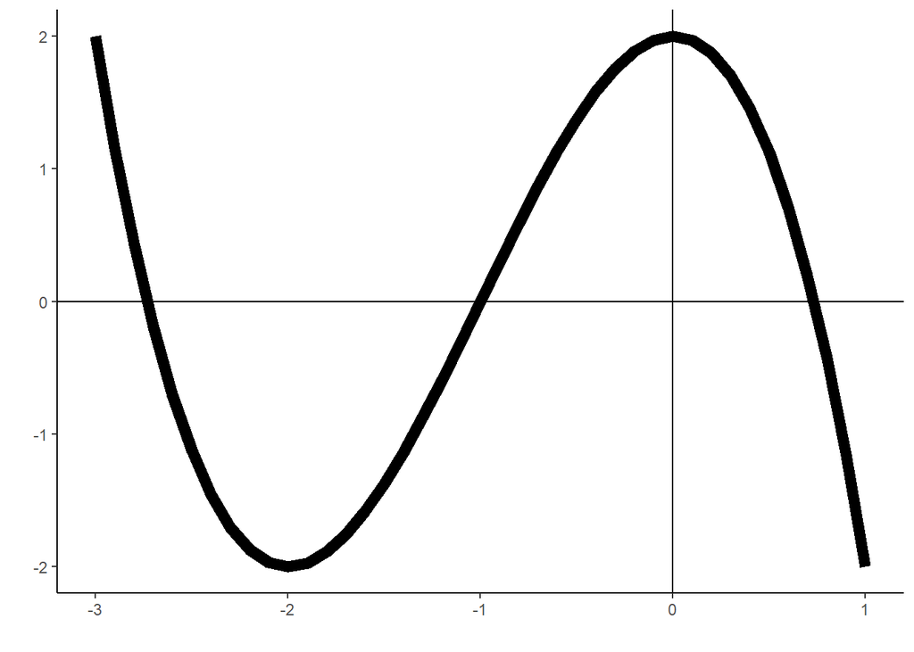

```r
x=seq(-3,1,by=.1)

y=-x^3-3*x^2+2

ggplot()+
  geom_hline(yintercept=0)+
  geom_vline(xintercept = 0)+
  geom_line(aes(x=x,y=y),color="black",size=3)+
  theme_classic()+
  labs(x="",y="")
```

3. Find the derivative of these equations
   1. $f(x)=\exp^{x^2+3}$
   2. $f(x)=\sqrt(2x)((x^3-4x+15))$
   3. $f(x)=\frac{x^3+2x}{x-1}$
4. Find the critical points of the function and determine whether they are maximum or minimum.

$$2x^3-5x^2+3x-12$$

5. Let’s solve the canonical Gordon-Schaefer fisheries production model. This model formed the basis of fisheries management for half a century and is still a widely used model. It starts by defining the change in the abundance or biomass of fish by the logistic growth equation:

$$\begin{equation}
\frac{dB}{dt}=rB(t)(1-\frac{B(t)}{K})
\end{equation}$$

where $B$ is biomass, $t$ is time, $r$ is the intrinsic growth rate, and $K$ is the carrying capacity. Next, fishers catch fish based on their effort $E$, technological ability $q$ (also called the catchability coefficient), and the amount of fish $B$. For simplicity, we use an easy multiplicative form:

$$Y=qEB$$

This catch or harvest rate takes away from the growth of the fish stock, thus we can subtract it from the logistic growth equation 1.

$$\begin{equation}
\frac{dB}{dt}=rB(t)(1-\frac{B(t)}{K})-Y
\end{equation}$$

**a)** Fishery managers are interested in finding the equilibrium level of biomass and harvest. We can set $\frac{dB}{dt}=0$. Solve for the equilibrium biomass in terms of K,q,r,E.

**b)** Sub the equilibrium biomass you found in A into the harvest equation.

**c)** What effort leads to a maximum sustainable yield? Maximize the equation from b) with respect to effort $E$.

**d)** Interpret what you found in c). What are the two variables that drive fisher harvest levels?

**e)** Calculate what the maximum sustainable yield by substituting the optimal harvest level into the harvest equation.